# **Panorama da inflação**

Os principais índices de inflação do Brasil, apontam em maio de 2008 um avanço da inflação de em média **1.12%**. Com esse resultado, no ano a inflação acumula uma variação média positiva de **3.27%**, e em 12 meses uma variação média acumulada de **7.92%**.

[output not shown]

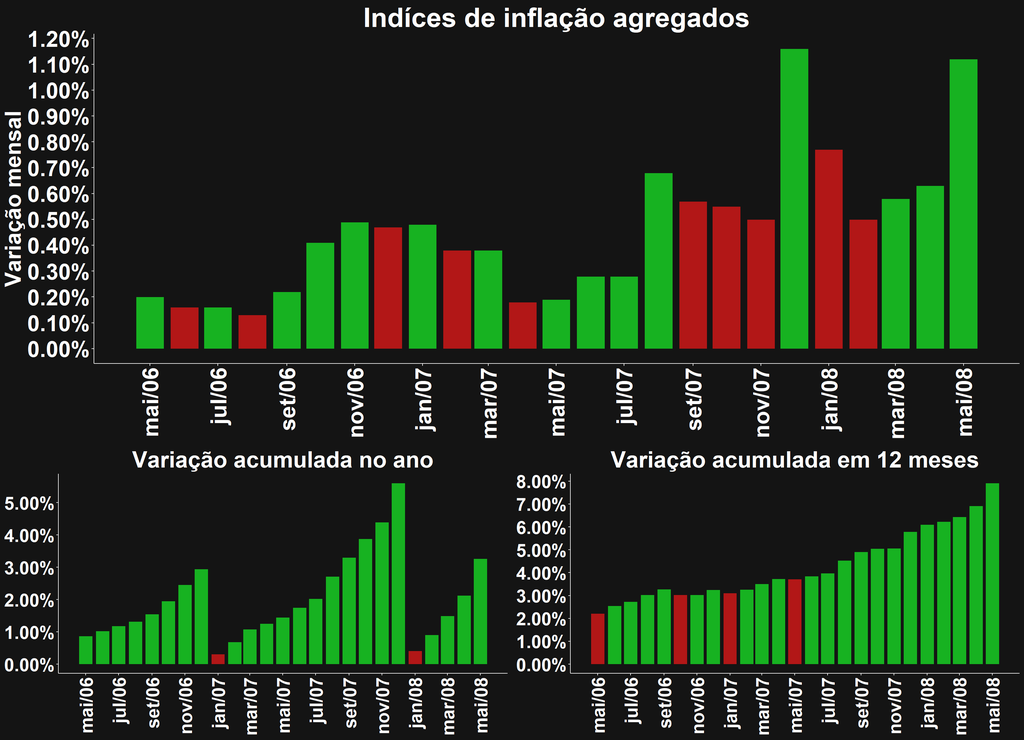

Índices selecionados para a média: IPCA, INPC e IGP-M.

# IPCA

O Indíce de Preços ao Consumidor Amplo (IPCA) variou 0.79% em maio, valor superior ao mesmo período do ano anterior quando apresentou uma taxa de 0.28%. Com esse resultado o indíce acumula no ano uma variação positiva de 2.88%, e em 12 meses uma variação positiva de 5.58%.

|  | 05/2007 | 04/2008 | 05/2008 |
| --- | --- | --- | --- |
| Variação mensal | 0.28% | 0.55% | 0.79% |
| Variação acumulada no ano | 1.79% | 2.08% | 2.88% |
| Variação acumulada em 12 meses | 3.18% | 5.04% | 5.58% |

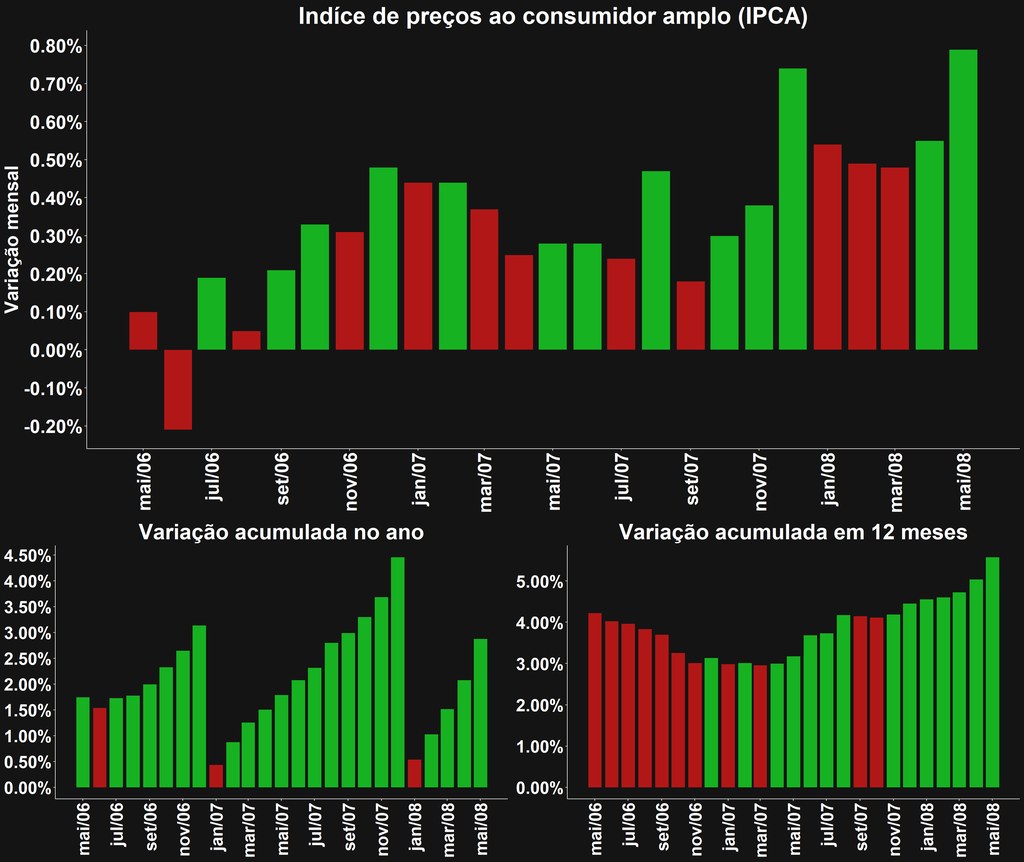

|  | Variação mensal | Variação acumulada no ano | Peso mensal |
| --- | --- | --- | --- |
| Alimentação e bebidas | 1.95% | 6.4% | 22.19% |
| Habitação | 0.32% | 1.53% | 13.15% |
| Artigos de residência | 0.17% | 0.16% | 4.32% |
| Vestuário | 0.98% | 2.65% | 6.52% |
| Transportes | 0.33% | 1.16% | 20.13% |
| Saúde e cuidados pessoais | 0.65% | 2.79% | 10.77% |
| Despesas pessoais | 1.11% | 2.8% | 9.69% |
| Educação | 0.03% | 4.01% | 7.16% |
| Comunicação | -0.02% | 0.26% | 6.08% |

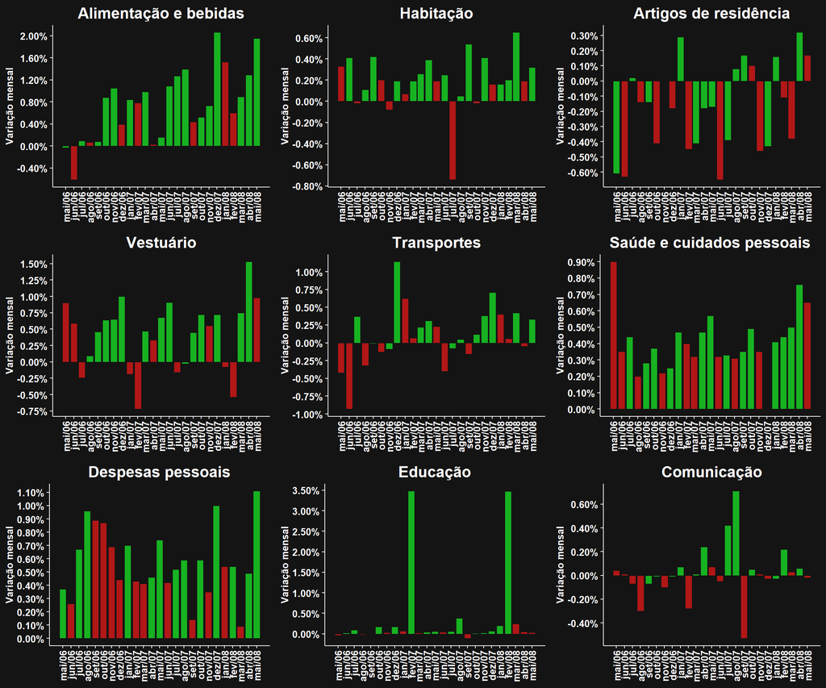

A nível de sub-itens os que mais influenciaram positivamente no resultado em relação ao seu peso foram Arroz (19.75%%) e Refeição (1.46%%), e negativamente Feijão - carioca (rajado)) (-11.26%%) e Energia elétrica residencial (-0.6%%).

|  | Variação mensal | Variação acumulada no ano | Peso mensal |
| --- | --- | --- | --- |
| Serviço bancário | 8.74% | 8.84% | 0.54% |
| Pão francês | 4.74% | 19.38% | 1.2% |
| Arroz | 19.75% | 25.74% | 0.54% |
| Refeição | 1.46% | 6.43% | 3.93% |

|  | Variação mensal | Variação acumulada no ano | Peso mensal |
| --- | --- | --- | --- |
| Energia elétrica residencial | -0.6% | -0.09% | 3.37% |
| Feijão - carioca (rajado)) | -11.26% | -14.71% | 0.35% |
| Mamão | -15.2% | 13.86% | 0.11% |
| Laranja - pera | -8.58% | 10% | 0.15% |

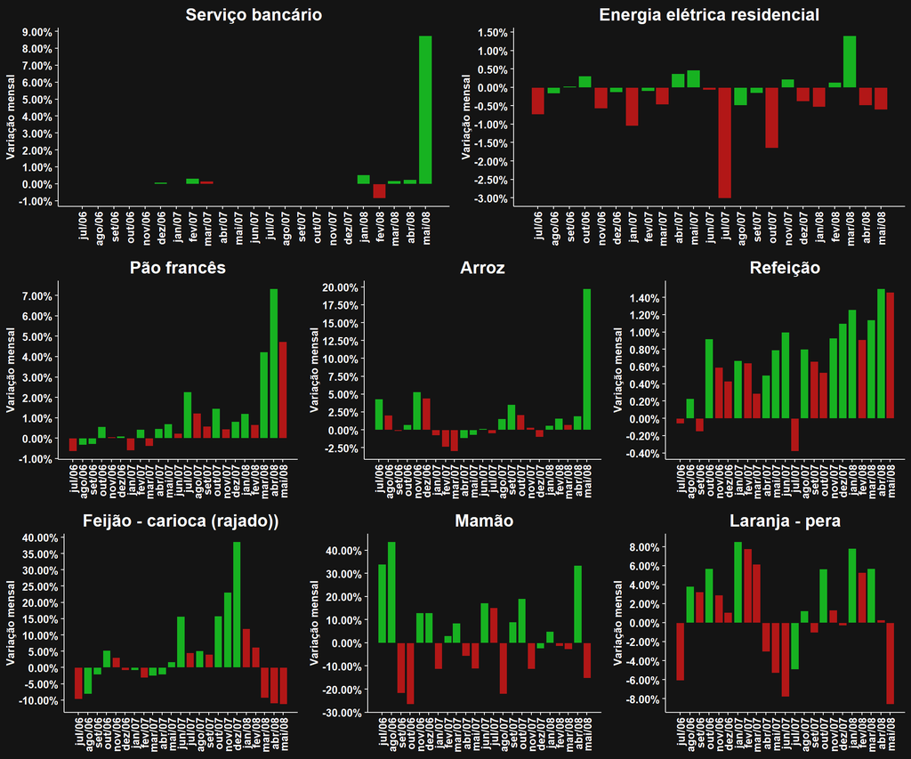

# INPC

O Indíce Nacional de Preços ao Consumidor (INPC) variou 0.96% em maio, valor superior ao mesmo período do ano anterior quando apresentou uma taxa de 0.26%. Com esse resultado o indíce acumula no ano uma variação positiva de 3.32%, e em 12 meses uma variação positiva de 6.64%.

|  | 05/2007 | 04/2008 | 05/2008 |
| --- | --- | --- | --- |
| Variação mensal | 0.26% | 0.64% | 0.96% |
| Variação acumulada no ano | 1.88% | 2.34% | 3.32% |
| Variação acumulada em 12 meses | 3.57% | 5.9% | 6.64% |

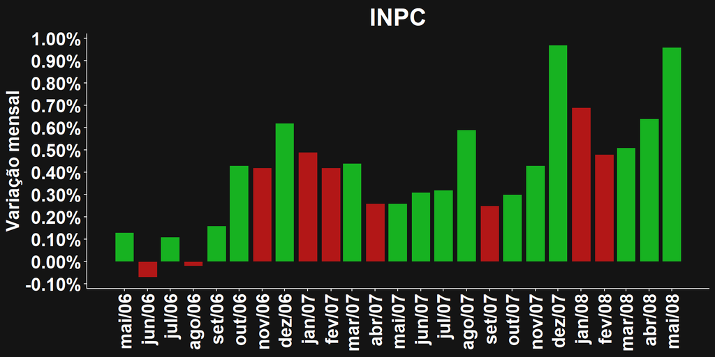

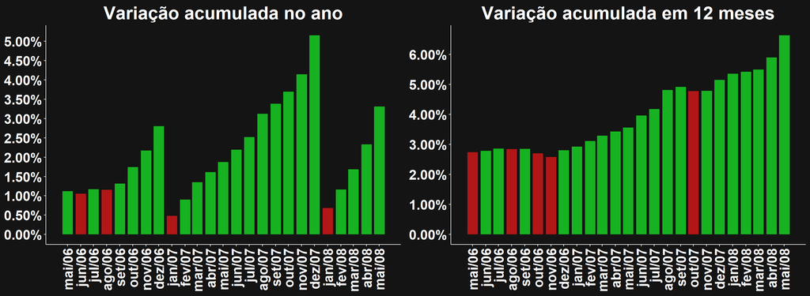

# IGP-M

O Indíce Geral de Preços de Mercado (IGP-M) variou 1.61% em maio, valor superior ao mesmo período do ano anterior quando apresentou uma taxa de 0.04%. Com esse resultado o indíce acumula no ano uma variação positiva de 3.61%, e em 12 meses uma variação positiva de 11.53%.

|  | 05/2007 | 04/2008 | 05/2008 |
| --- | --- | --- | --- |
| Variação mensal | 0.04% | 0.69% | 1.61% |
| Variação acumulada no ano | 0.69% | 1.97% | 3.61% |
| Variação acumulada em 12 meses | 4.4% | 9.81% | 11.53% |

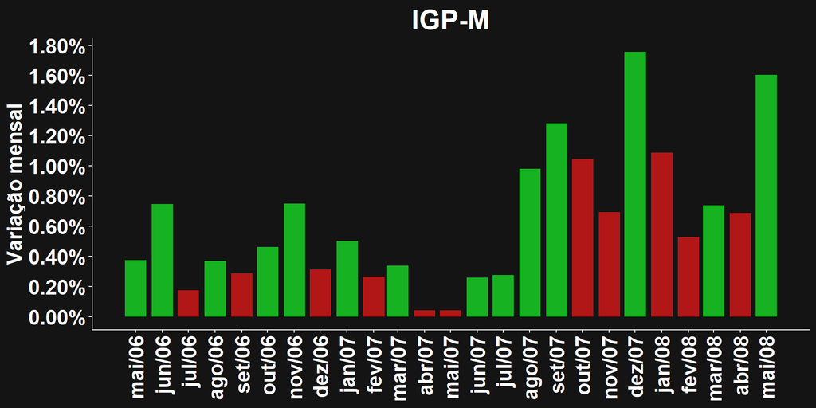

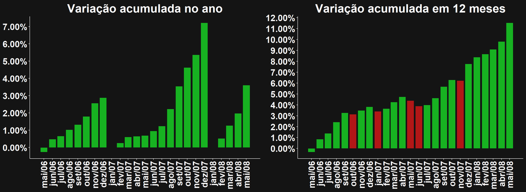

# IGP-DI

O Indíce Geral de Preços - Disponibilidade Interna (IGP-DI) variou 1.88% em maio, valor superior ao mesmo período do ano anterior quando apresentou uma taxa de 0.16%. Com esse resultado o indíce acumula no ano uma variação positiva de 4.13%, e em 12 meses uma variação positiva de 12.14%.

|  | 05/2007 | 04/2008 | 05/2008 |
| --- | --- | --- | --- |
| Variação mensal | 0.16% | 1.12% | 1.88% |
| Variação acumulada no ano | 0.75% | 2.21% | 4.13% |
| Variação acumulada em 12 meses | 4.38% | 10.24% | 12.14% |

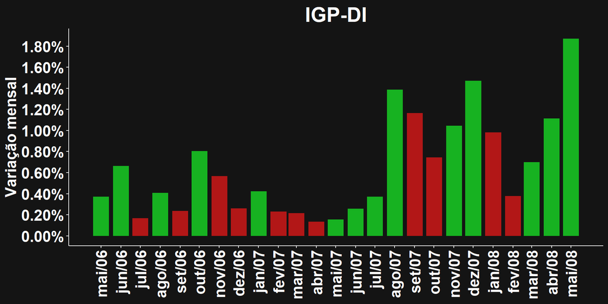

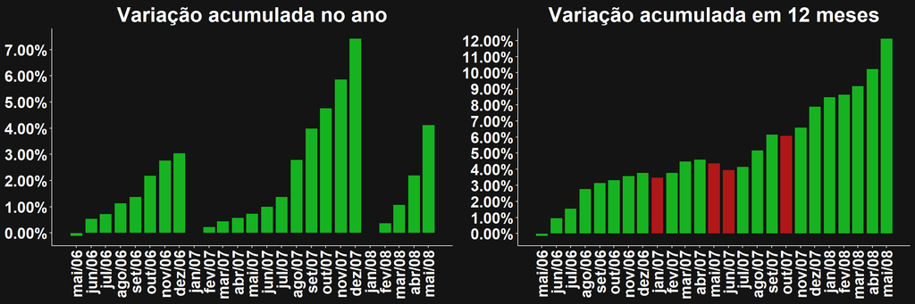

[output not shown]

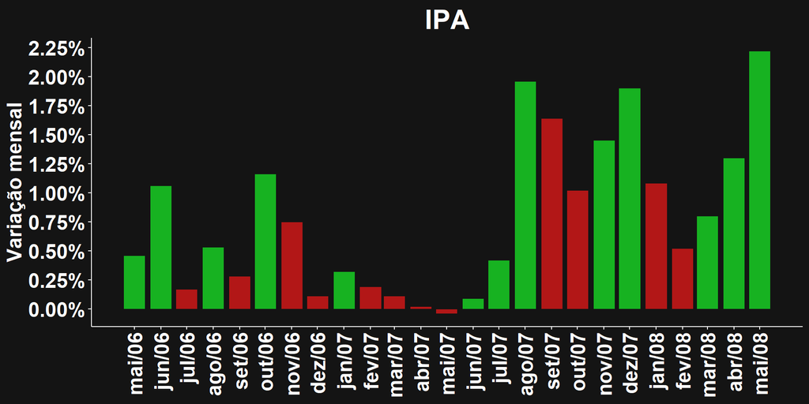

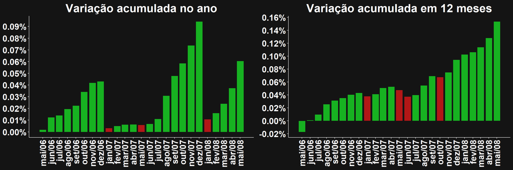

O Indíce de Preços ao Consumidor (IPC), integrante do IGP-DI com peso de 30%, apresentou variação de 0.87% em maio, valor superior ao mesmo período do ano anterior quando apresentou uma taxa de 0.25%. Com esse resultado o indíce acumula no ano uma variação positiva de 2.06%, e em 12 meses uma variação positiva de 5.59%.

|  | 05/2007 | 04/2008 | 05/2008 |
| --- | --- | --- | --- |
| Variação mensal | 0.25% | 0.72% | 0.87% |
| Variação acumulada no ano | 1.39% | 1.18% | 2.06% |
| Variação acumulada em 12 meses | 3.12% | 4.95% | 5.59% |

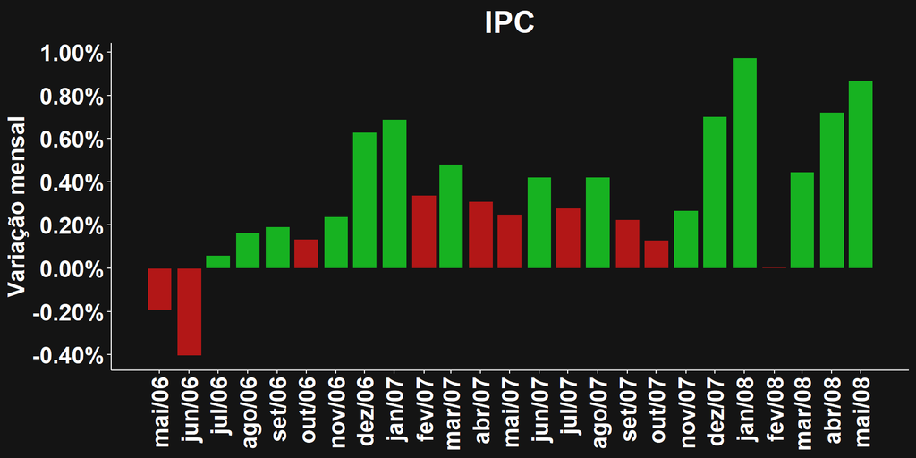

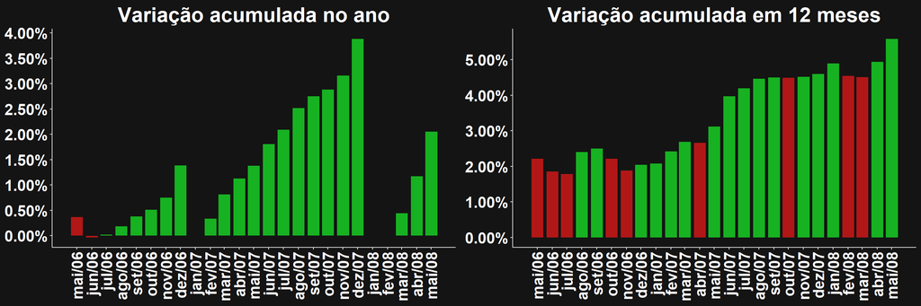

O Indíce Nacional de Custos de Construção (INCC), integrante do IGP-DI com peso de 10%, apresentou variação de 2.02% em maio, valor superior ao mesmo período do ano anterior quando apresentou uma taxa de 1.15%. Com esse resultado o indíce acumula no ano uma variação positiva de 4.01%, e em 12 meses uma variação positiva de 8.06%.

|  | 05/2007 | 04/2008 | 05/2008 |
| --- | --- | --- | --- |
| Variação mensal | 1.15% | 0.87% | 2.02% |
| Variação acumulada no ano | 2.1% | 1.95% | 4.01% |
| Variação acumulada em 12 meses | 5.18% | 7.13% | 8.06% |

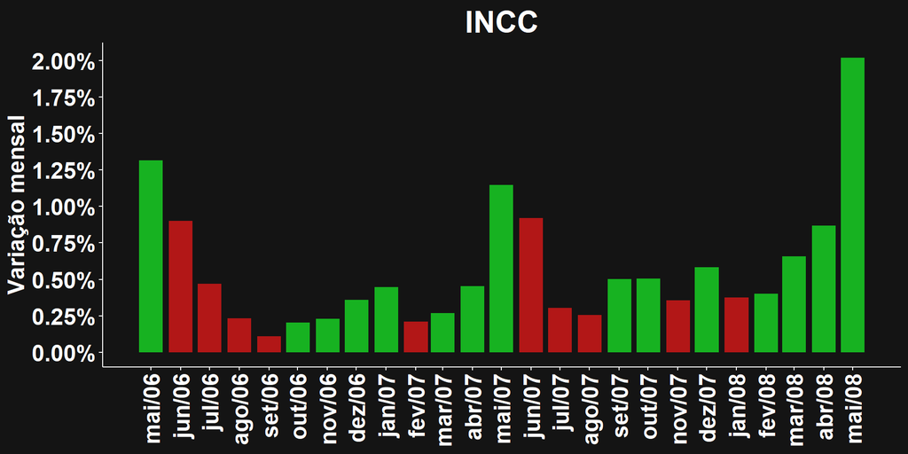

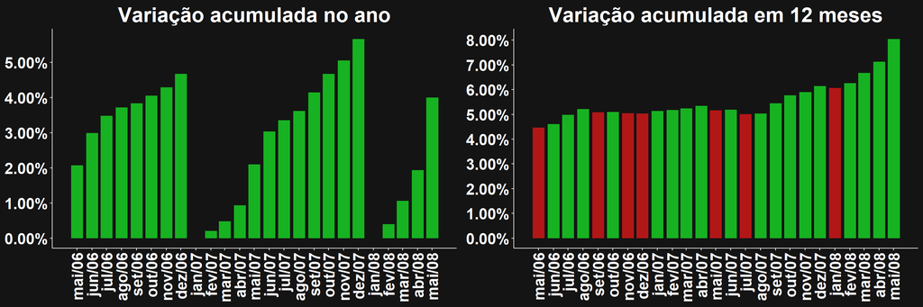

# Estatísticas

As estatísticas descritivas a seguir são feitas com base nos últimos 48 meses, e tem como objetivo possibilitar a avaliação do resultado observado em comparação aos períodos anteriores.

|  | Minimo | 1 Quartil | Mediana | Media | 3 Quartil | Maximo | Desvio Padrão |
| --- | --- | --- | --- | --- | --- | --- | --- |
| IPCA | -0.21% | 0.27% | 0.44% | 0.43% | 0.58% | 0.91% | 0.24% |
| INPC | -0.11% | 0.22% | 0.42% | 0.4% | 0.57% | 0.97% | 0.27% |
| IGP-M | -0.65% | 0.24% | 0.43% | 0.49% | 0.83% | 1.76% | 0.55% |
| IGP-DI | -0.79% | 0.21% | 0.42% | 0.49% | 0.81% | 1.88% | 0.55% |
| IPA | -1.04% | 0.09% | 0.47% | 0.53% | 1.06% | 2.22% | 0.77% |
| IPC | -0.44% | 0.13% | 0.35% | 0.37% | 0.64% | 0.97% | 0.33% |
| INCC | 0.02% | 0.27% | 0.45% | 0.57% | 0.73% | 2.09% | 0.44% |

Levando em consideração o desvio padrão de cada indíce, proporcionalmente os que mais se afastaram da média foram o INCC, o IGP-DI e o IPA.

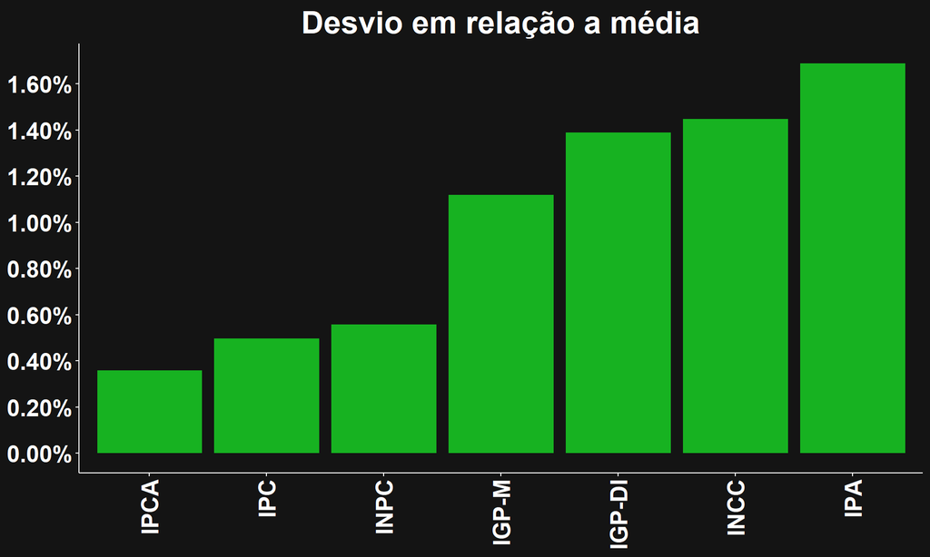

**João Victor Gomes**  
**jvg.santana@gmail.com**  
**[linkedin.com/in/jvictorgomes](https://www.linkedin.com/in/jvictorgomes/)**